# Georeferencing data gain

Igor Ferreira do Nascimento

2019-07-08

## Introduction

When you are looking for a new house you investigate the neighborhood environment. It’s happening because the relevant variables associated with the creators of majority people such as safety, infrastructure and pollution rather than being idiosyncratic is at least locally common. Thus, we can considerate that those variables help us to understand the geographic dependency concept.

This situation is an intuitive and practical view of the Waldo Tobler’ First Law of Geography “everything is related to everything else, but near things are more related than distant things.” Tobler (1970).

This Vignettes use the geobr package to understand the spatial effect in the Brazilian administrative data analysis.

## Fertility and years of schooling

There are many studies that associate the years of schooling and fertility. The work of Osili and Long (2008) analyse the educational policies in girls and young women and its impact in fertility and GDP.

In our example we analyse the impact on estimates coefficients and model specification in reason add geographical variables in regression model associating eductation level and fertility rate on cities of Rondônia state in Brazil using the package Pereira et al. (2019). The cities data are avaliable in http://atlasbrasil.org.br/2013/pt/download/.

The model will be used to explain the years of schooling as a function of the fertility rate in the municipalities when the georefining variables are incorporated into the model. The following figure shows the years of schooling and the fertility rate.

```r
library(devtools)
library(digest)

# devtools::install_github("ipeaGIT/geobr")
library(geobr)

library(spdep)
library(spgwr)
library(RColorBrewer)
library(readxl)
library(dplyr)
library(ggplot2)
library(rio)

adh <- rio::import("http://atlasbrasil.org.br/2013/data/rawData/atlas2013_dadosbrutos_pt.xlsx",
                   which = "MUN 91-00-10")

adh <- adh %>%
  dplyr::select(ANO,UF,Codmun7,
         E_ANOSESTUDO,FECTOT,
         RAZDEP,IDHM)

adh_2010 <- adh %>%
  filter(ANO==2010)

shape <- read_municipality(code_muni = "all", year = 2010)
```

```
#> Using data from year 2010
```

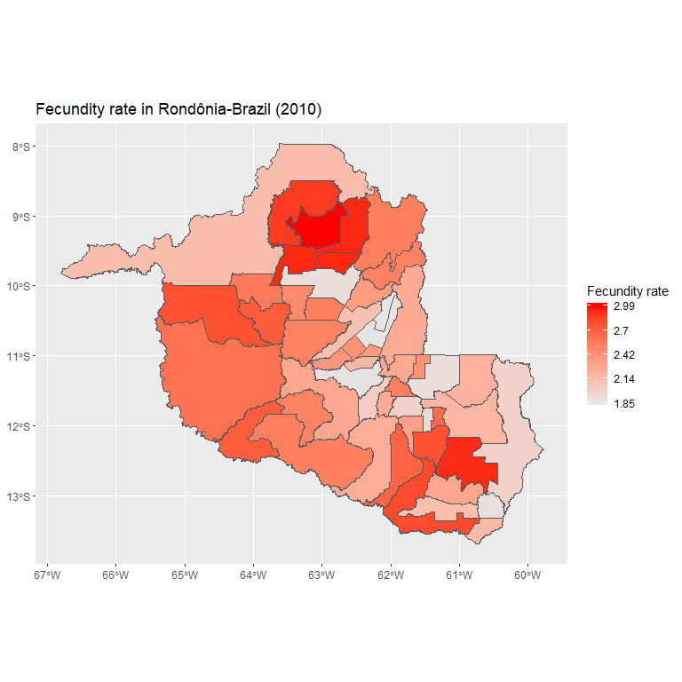

```r
shape <- shape %>%
  filter(substr(code_muni,1,2)=="11") %>%
  left_join(adh_2010,by = c("code_muni"="Codmun7"))


brks <- seq(from = range(shape$FECTOT)[1],
            to = range(shape$FECTOT)[2],
            length.out =5)

ggplot(shape) +
  geom_sf(aes(fill=FECTOT)) +
  scale_fill_gradient(high = "red",
                      low= "grey90", name="Fecundity rate",
                       labels = round(brks,2),
                       breaks = brks) +
  labs(title = "Fecundity rate in Rondônia-Brazil (2010)")
```

The following figure shows the years of schooling and the fertility rate.

```r
adh <- rio::import("http://atlasbrasil.org.br/2013/data/rawData/atlas2013_dadosbrutos_pt.xlsx",
                   which = "MUN 91-00-10")


adh <- adh %>%
  dplyr::select(ANO,UF,Codmun7,
         E_ANOSESTUDO,FECTOT,
         RAZDEP,IDHM)

adh_2010 <- adh %>%
  filter(ANO==2010)

shape <- read_municipality(code_muni = 11, year = 2010)
```

```
#> Using data from year 2010
```

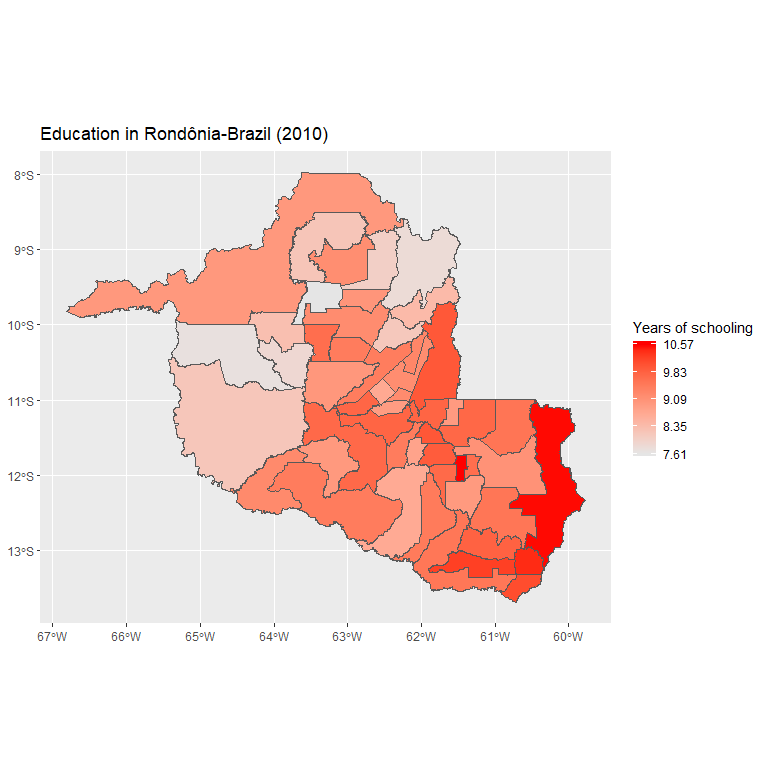

```r
shape <- shape %>%
  left_join(adh_2010,by = c("code_muni"="Codmun7"))


brks <- seq(from = range(shape$E_ANOSESTUDO)[1],
            to = range(shape$E_ANOSESTUDO)[2],
            length.out =5)

ggplot(shape) +
  geom_sf(aes(fill=E_ANOSESTUDO)) +
  scale_fill_gradient(high = "red",
                      low= "grey90", name="Years of schooling",
                       labels = round(brks,2),
                       breaks = brks) +
  labs(title = "Education in Rondônia-Brazil (2010)")
```

A regression model is fitted using ordinary least squares and one using the Geographically Weighted Regression model (GWR) Bivand and Yu (2017)

The GWR model can be represented by Li et al. (2019):

$$y_i = \beta_0(u_i,v_i) + \sum_{j=1}^k \beta_j(u_i,v_i)x_{ij}+\varepsilon_i$$

where $y_i$ is the dependent variable, $x_ {ij}$ the independent variables, $ beta_j $ the regression coefficients in the space $(u_i, v_i)$ of the unit $ i $ and $ _i$ the model’s residual. The model parameters estimating for unit $ i $ is impacted by other units and the dependece is determined by distance matrix $W$ Li et al. (2019). This influence decreases as units move away from unit $ i $.

Although there are complex situations and approach in the distance calculation, the mostly distance matrix are continuous measures instead of the binary measure of neighborhood Hijmans and Ghosh (2019).

For this example we will use the Gaussian distance:

$$W(i,j) = e^{{-(d_{i,j}/h)}^2}$$
where $d_{i,j}$ is the Euclidean distance and $h$ is the bandwidth parameter that can be determined by cross validation. Regression models via OLS and GWR can be fitted by following code.

```r
bandwidth <- gwr.sel(E_ANOSESTUDO ~ FECTOT, data=as(shape, "Spatial"))
```

```
#> Bandwidth: 266.6882 CV score: 18.27661
#> Bandwidth: 431.0797 CV score: 19.94032
#> Bandwidth: 165.0886 CV score: 16.13708
#> Bandwidth: 102.2966 CV score: 14.91684
#> Bandwidth: 63.48905 CV score: 15.54461
#> Bandwidth: 105.9699 CV score: 14.96434
#> Bandwidth: 94.69638 CV score: 14.84107
#> Bandwidth: 82.77624 CV score: 14.82838
#> Bandwidth: 87.56929 CV score: 14.81198
#> Bandwidth: 87.89058 CV score: 14.81209
#> Bandwidth: 87.50769 CV score: 14.81198
#> Bandwidth: 87.47991 CV score: 14.81198
#> Bandwidth: 87.48049 CV score: 14.81198
#> Bandwidth: 87.48053 CV score: 14.81198
#> Bandwidth: 87.48057 CV score: 14.81198
#> Bandwidth: 87.48053 CV score: 14.81198
```

```r
gwr_model <- gwr(E_ANOSESTUDO ~ FECTOT,
                 data=as(shape, "Spatial"),
                 bandwidth=bandwidth,
                 hatmatrix=TRUE)

ols_model <- lm(E_ANOSESTUDO ~ FECTOT,
                data=shape)

shape$residuals_ols <- ols_model$residuals
shape$residuals_gwr <- gwr_model$SDF$pred-shape$E_ANOSESTUDO

model_gwr_data <- gwr_model$SDF@data
model_gwr_data$code_muni <- shape$code_muni

model_gwr_data <- model_gwr_data %>%
  dplyr::select(code_muni,X.Intercept.,FECTOT)
names(model_gwr_data) <- c("code_muni","Intercept","Slope")
shape <- shape %>%
  left_join(model_gwr_data,by = "code_muni")

quantile(shape$Slope)
```

```
#>         0%        25%        50%        75%       100%
#> -2.2387595 -0.9258792 -0.7926039 -0.6448670 -0.4843702
```

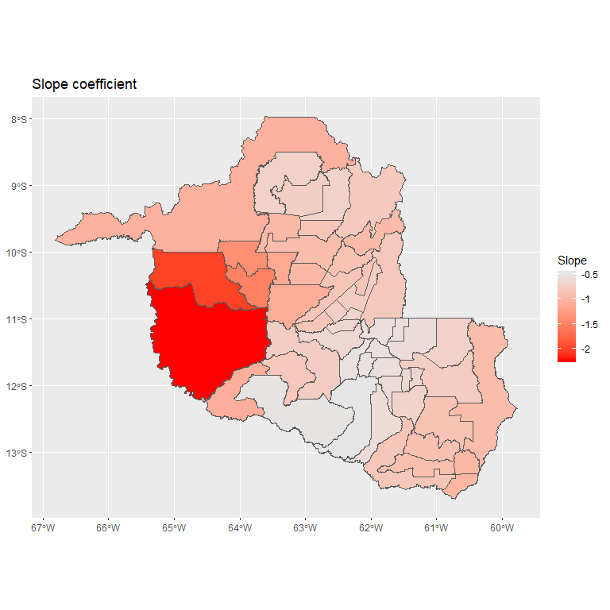

```r
bks <- seq(-2.5,0,by=.5)

ggplot(shape) +
  geom_sf(aes(fill=Slope)) +
  scale_fill_gradient(high = "grey90",
                      low= "red", name="Slope",
                       labels = round(bks,2),
                       breaks = bks) +
  labs(title = "Slope coefficient")
```

The slope coefficient show the negative relationship between years of schooling and fertility agreeing to work of Osili and Long (2008).

```r
quantile(shape$Intercept)
```

```
#>       0%      25%      50%      75%     100%
#> 10.43480 10.79278 11.05622 11.64313 14.37141
```

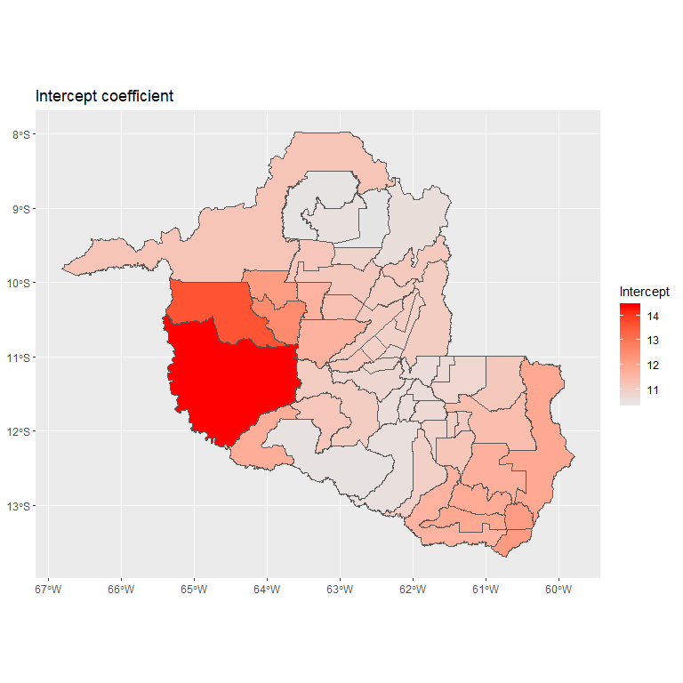

```r
bks <- seq(10,15,by=1)

ggplot(shape) +
  geom_sf(aes(fill=Intercept)) +
  scale_fill_gradient(high = "red",
                      low= "grey90", name="Intercept",
                       labels = round(bks,2),
                       breaks = bks) +
  labs(title = "Intercept coefficient")
```

Similar to temporal autocorrelation, spatial autocorrelation measures the similarity of units based on their spatial position, which may be exogenous or endogenous, and is mostly calculated by the Moran Index Hijmans and Ghosh (2019).

Based on the qqplot graph and the Shapiro-Wilk statistic there is evidence to reject the hypothesis of residual normality in the OLS model. Besides that, the residues analyzed present evidence of spatial autocorrelation, confirmed by the Moran Index. Thus, the residuals suggests that the model is not correctly specified and that there could be “neglected information” due ignored geographic positioning variables.

```r
nb <- poly2nb(as(shape, "Spatial"))
lw <- nb2listw(nb)


quantile(shape$residuals_ols)
```

```
#>          0%         25%         50%         75%        100%
#> -1.22303701 -0.55092184 -0.03253531  0.54742764  0.95889002
```

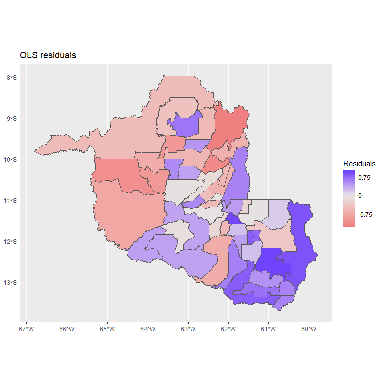

```r
bks <- seq(from = -1.5,
            to = 1.5,
            length.out =5)

ggplot(shape) +
  geom_sf(aes(fill=residuals_ols)) +
  scale_fill_gradient2(high = "blue", low= "lightcoral",
                       mid = "grey90", name="Residuals",
                      labels = round(bks,2),
                      breaks = bks) +
  labs(title = "Residuals distribuition") +
  labs(title = "OLS residuals")
```

```r
moran.mc(shape$residuals_ols,
         lw, 999)
```

```
#>
#>  Monte-Carlo simulation of Moran I
#>
#> data:  shape$residuals_ols
#> weights: lw
#> number of simulations + 1: 1000
#>
#> statistic = 0.29043, observed rank = 1000, p-value = 0.001
#> alternative hypothesis: greater
```

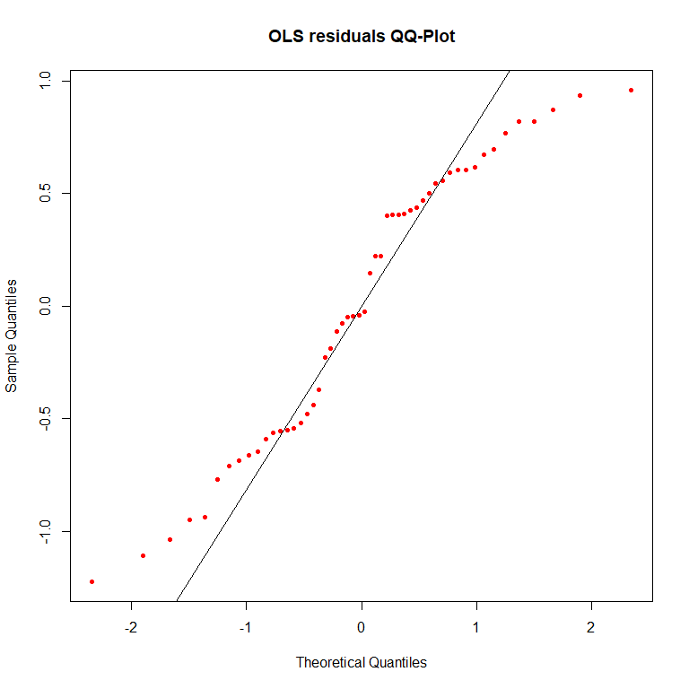

```r
qqnorm(shape$residuals_ols,col=2,pch = 20,
       main = "OLS residuals QQ-Plot")
qqline(shape$residuals_ols)
```

```r
shapiro.test(shape$residuals_ols)
```

```
#>
#>  Shapiro-Wilk normality test
#>
#> data:  shape$residuals_ols
#> W = 0.94183, p-value = 0.0133
```

whereas that when we use the GWR model the spatial information are inserted in the parameters estimation of model. As show on graphs following , there is no statistical evidence of spatial autocorrelation in the GWR model residuals. In addition, there is no evidence of violation of the normality assumption.

```r
quantile(shape$residuals_gwr)
```

```
#>          0%         25%         50%         75%        100%
#> -0.78818048 -0.30750053 -0.02259427  0.35377469  0.88056520
```

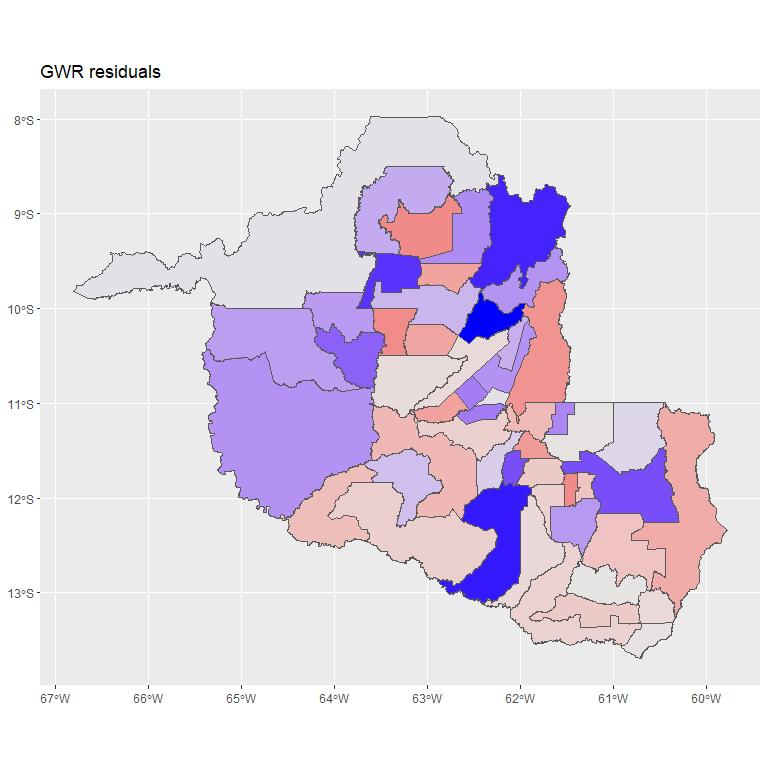

```r
brk <- seq(from = -1,
            to = 1,
            length.out =5)


ggplot(shape) +
  geom_sf(aes(fill=residuals_gwr)) +
  scale_fill_gradient2(high = "blue", mid= "grey90",
                       low = "lightcoral",
                       name="Residuals",
                       labels = round(brk,2),
                       breaks = brks) +
  labs(title = "GWR residuals")
```

```r
moran.mc(shape$residuals_gwr,
         lw, 999)
```

```
#>
#>  Monte-Carlo simulation of Moran I
#>
#> data:  shape$residuals_gwr
#> weights: lw
#> number of simulations + 1: 1000
#>
#> statistic = -0.11711, observed rank = 105, p-value = 0.895
#> alternative hypothesis: greater
```

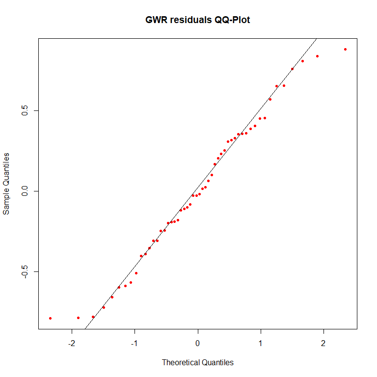

```r
qqnorm(shape$residuals_gwr,col=2,pch = 20,
       main = "GWR residuals QQ-Plot")
qqline(shape$residuals_gwr)
```

```r
shapiro.test(shape$residuals_gwr)
```

```
#>
#>  Shapiro-Wilk normality test
#>
#> data:  shape$residuals_gwr
#> W = 0.97456, p-value = 0.3266
```

## References

Bivand, Roger, and Danlin Yu. 2017. *Spgwr: Geographically Weighted Regression*. https://CRAN.R-project.org/package=spgwr.

Hijmans, Robert J., and Aniruddha Ghosh. 2019. “Spatial Data Analysis with R.” 2019. https://www.rspatial.org/analysis/index.html.

Li, Shijie, Chunshan Zhou, Shaojian Wang, Shuang Gao, and Zhitao Liu. 2019. “Spatial Heterogeneity in the Determinants of Urban Form: An Analysis of Chinese Cities with a Gwr Approach.” *Sustainability* 11 (2). Multidisciplinary Digital Publishing Institute:479.

Osili, Una Okonkwo, and Bridget Terry Long. 2008. “Does Female Schooling Reduce Fertility? Evidence from Nigeria.” *Journal of Development Economics* 87 (1). Elsevier:57–75.

Pereira, Rafael H. M., Caio Nogueira Goncalves, Guilherme Duarte Carvalho, Paulo Henrique Fernandes de Araujo, Rodrigo Almeida de Arruda, and Igor Nascimento. 2019. *Geobr: Loads Shapefiles of the Brazilian Institute of Geography and Statistics (Ibge)*. https://github.com/ipeaGIT/geobr.

Tobler, Waldo R. 1970. “A Computer Movie Simulating Urban Growth in the Detroit Region.” *Economic Geography* 46 (sup1). Taylor & Francis:234–40.